# Part II - Effects of gender, and user type, on trip duration

## by Joseph Mburu

## Investigation Overview

> For the presentation, I primarily focused on the effects of gender and user type on trip duration. These variables are selected for presentations because they showed clear relationship without ambiguity. I will start by showing the distribution of the trip duration variable after log transformation. I will then introduce the categorical variables, one by one to get insights into the relationship between each of the categorical variable and trip duration. The relationship will be polished using box plots and clustered bar chart.

## Dataset Overview

> The data consisted of trip duration and attributes of approximately 183,412 bike riders. The attributes included 16 features as well as other additional variables such as age, start day and end day. After removing observations with missing values, the data contained 174,952 bike riders.

## Distribution of Trip duration

> The trip duration variables assumes a wide range of values ranging from 0 to 80,000 seconds. However, when plotted on a logarithmic scale, the distribution is unimodal with peaks between 200 and 1000 seconds.

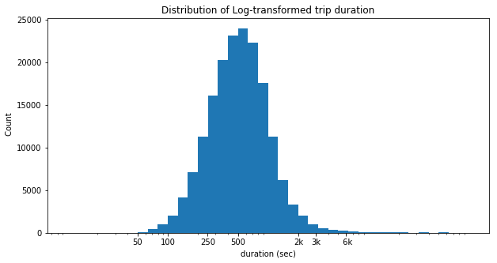

## Gender vs. trip duration

> To investigate the relationship between gender and trip duration, a box plot was plotted. The box plots showed that there were many outliers in the trip duration. Thus, to get a clear visual of the relationship, we limited the number of observations to 3000 seconds. The results showed that male bike riders completed the trip faster than female bike riders.

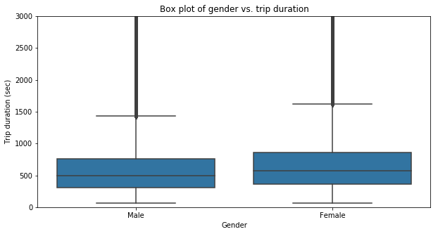

## User type vs. trip duration

> To gain more insights into the association between user type and trip duration, a box plot was plotted. There were many outliers on the upper part of the distribution and this was countered by limiting the duration to 3000 seconds when plotting. The box plot showed that subscribers completed the trip faster than customers.

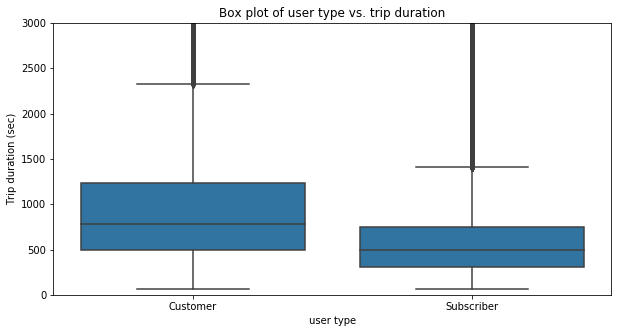

## User type vs. Gender

> To investigate the association between gender and user type, a clustered bar chart was plotted. The results showed that the number of males who were either customer or subscribers were more than females who were either customers or subscribers.

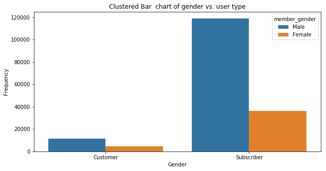